# Support Vector Machines

## Einleitung

Es wird die library `e1071` in `R` benutz, um die die Methodik der SVM zu veranschaulichen.

*(note: das Paket wurde nach des Raum an der TU Wien benannt, in dem es geschrieben wurde)*

```r
rm(list = ls(all = TRUE))
library(e1071)
library(dplyr)
```

## Maximal Margin Classifier

### Erstellen eines Beispieldatansatzes

Im ersten Schtitt wird zur Veranschaulichung ein fiktiver Trainingsdatensatz erstellt: $S = \left\lbrace \left(\mathbf{x}^{(i)}, y^{(i)}\right )\mid i, \ldots, 10, \mathbf{x}^{(i)} \in \mathbb{R}^2, y^{(i)} \in \left\lbrace-1,1\right\rbrace \right\rbrace$

Das Resultat liefert eine Menge an $\mathbf{x}^{(i)}$ die hinsichtlich ihrer $y^{(i)}$ linear Trennbar sind.

```r
set.seed(1987)
N <- 10
x <- data.frame(X1 = c(runif(N/2,1,5), runif(N/2,1,5) + 3),
                X2 = c(runif(N/2,1,5), runif(N/2,1,5) + 3))
y = c(rep(-1,N/2),rep(1, N/2))
head(cbind(x, y))
```

|  | X1 | X2 | y |
| --- | --- | --- | --- |
| 1 | 1.395057 | 3.423528 | -1 |
| 2 | 4.220194 | 3.974871 | -1 |
| 3 | 3.430296 | 3.873423 | -1 |
| 4 | 2.531329 | 1.712543 | -1 |
| 5 | 4.991215 | 2.187918 | -1 |
| 6 | 7.969705 | 5.869525 | 1 |

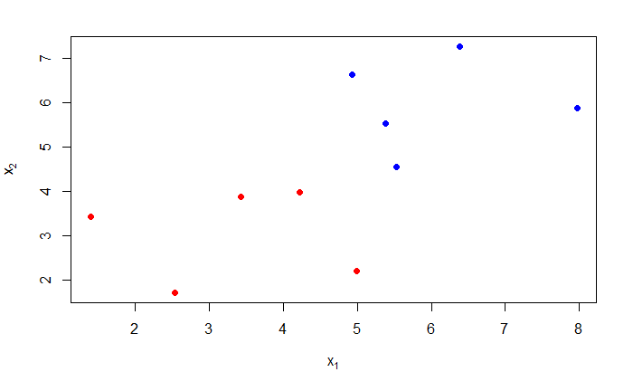

```r
plot(x, col = (y + 3),
     pch = 19,
     xlab = expression(x[1]),
     ylab = expression(x[2])
)
```

### Schätzung

Mit der Funktion `svm()`aus dem Paket `e1071` kann das eingeschränkte Optimierungsproblem gelöst werden.  
$\underset{\mathbf{w},b}{\min} \frac{1}{2}||\mathbf{w}|| + C \sum_{i=1}^{N} \xi_i$,  
u.d.N. $y^{(i)}(\mathbf{w}^T\mathbf{x}^{(i)} +b ) \geq 1 - \xi_i$, $1,\ldots,N$

Die Visualisierung erfolgt über `plot()`, jedoch ist man hier recht beschränkt in den Möglichkeiten der Parametrisierungen und die Axes sind vertauscht.

*(Anmerkung: der Kostenparameter $C$ ist default auf 1 gesetzt und durch* `scale = TRUE` *werden die Daten normiert auf $\mu$ = 0 und $\sigma^2$= 1)*

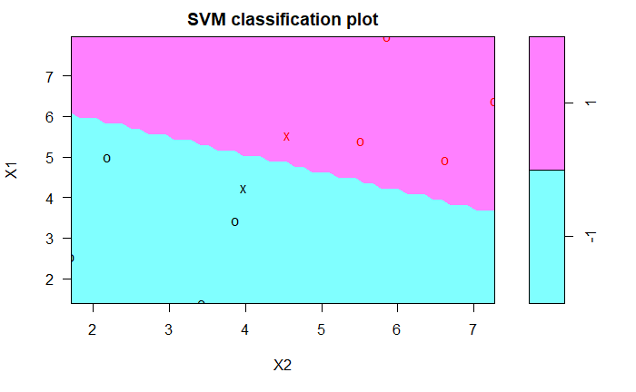

```r
df <- cbind(x, y = factor(y))
svmfit <- svm(y~., data = df,
              kernel = "linear",
              cost = 1,
              scale = FALSE)
plot(svmfit, df)
```

### Zusammenfassung

```r
summary(svmfit)
```

```
Call:
svm(formula = y ~ ., data = df, kernel = "linear", cost = 1, scale = FALSE)


Parameters:
   SVM-Type:  C-classification
 SVM-Kernel:  linear
       cost:  1
      gamma:  0.5

Number of Support Vectors:  2

 ( 1 1 )


Number of Classes:  2

Levels:
 -1 1
```

Hinter der Funktion `svm()` verbergen sich viele nützliche Eigenschaften. Möchte man z.B. die Indeces der Support Vektoren haben, dann so geht das über:

```r
svmfit$index
```

```
[1] 2 7
```

### Plot selber generieren

Hier folgt eine Methode das Resultat im $\mathbb{R}^2$ selber zu plotten.  
Hierfür wird eine Funktion `plot_svm()` geschrieben, mit der Idee ein eingefärbtes Raster über den eingeschränkten Merkmalsraum zu legen und die Hyperbene sowie die Klassengrenze einzuzeichen.

> Neue Beobachtungen $\mathbf{x}^*$ lassen sich leicht mit der Funktion `predict()` klassifizieren.

```r
plot_svm <- function(model, x, y, n = 75){

  # Bedingungen
    stopifnot(model$scaled == FALSE,
              nrow(x) == length(y),
              class(y) == "factor"
              )
  # Erstellen eines Raster
  range_x <- apply(x, 2, range)
  x1 <- seq(range_x[1,1], range_x[2,1], length = n)
  x2 <- seq(range_x[1,2], range_x[2,2], length = n)
    ## expand.grid erstellt eine Matrix mit allen möglichen Kombinatione der Elemenete der Eingabevektoren
    x_grid <- expand.grid(X1 = x1, X2 = x2)
    names(x_grid) <- names(x)
    y_grid <- predict(model, x_grid)

  # Plotten des Rasters
  plot(x_grid,
       col = c("red", "blue")[as.numeric(y_grid)],
       pch = 20,
       cex = .2,
       ann = FALSE,
       xlim = c(min(x1), max(x1)),
       ylim = c(min(x2), max(x2)))

  # Text Outputs
  title(main = "SVM Classification Plot",
        xlab = substitute(paste(X[1], " = ", x1), list(x1 = names(x)[1]) ),
        ylab = substitute(paste(X[2], " = ", x2), list(x2 = names(x)[2]) ),
        sub  = substitute(paste(w^T, " = (", w1, "," , w2, ");     b = ", b, ";     cost = ", c),
                          list(w1 =  round(drop(t(model$coefs) %*% as.matrix(x[model$index,]))[1], 2),
                               w2 =  round(drop(t(model$coefs) %*% as.matrix(x[model$index,]))[2], 2),
                               b =   round(model$rho, 2),
                               c = model$cost
                               )),
        ## Textformatierungen
        col.main = "Skyblue",
        cex.main = 1.8,
        font.main = 7)

  # Trainingspunkte
  points(x, bg = c("red", "blue")[y], pch = 21, cex = 1.5)
  # Support Vectors
  points(x[model$index,], pch = 9, cex = 3)

  # Hyperbene und Klassengrenzen.
  if (model$kernel == 0){

  w <- drop(t(model$coefs) %*%  as.matrix(x[model$index,]))
  b <- model$rho
  ## Hyperebene
  abline(b / w[2], -w[1] / w[2], lwd = 2.5)

  ## Klassengrenzen
  abline((b - 1) / w[2] , -w[1] / w[2], lty = 2, lwd = 2)
  abline((b + 1) / w[2] , -w[1] / w[2], lty = 2, lwd = 2)

}
  }
```

Die Funktion `plot_svm()` wird nun auf die Trainingsdaten angewendet.

- Die Hyperbene ist als durchgezogen Linie und die Klassengrenzen als dotted.
- Entscheidungsregeln im sichtbaren Merkmalsraum sind farblich eingefärbt
- die Support Vector sind mit einem Viereck versehen

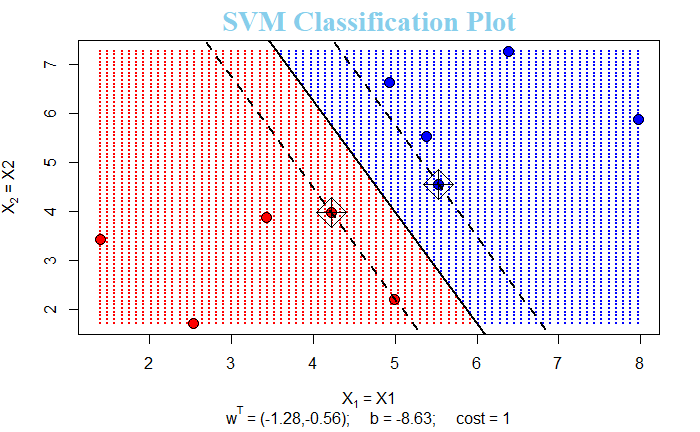

```r
plot_svm(model = svmfit, x = df[,1:2], y = df$y)
```

## Support Vector Classifier

Um nun eine Trainingsmenge zu erzeugen, die nicht mehr linear Trennbar sind, wird der Datensatz um ein Trainingspunkt so erweitert, dass die Klassen nicht mehr linear trennbar jedoch aber überlappend sind: $(\mathbf{x}^{(11)} = (5, 6), -1)$

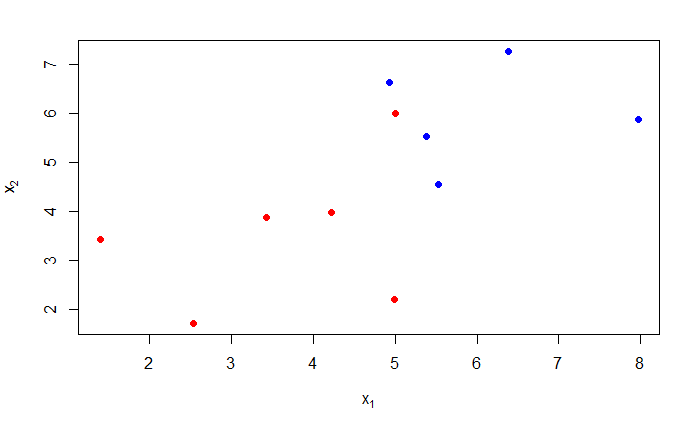

```r
x <- rbind(x, c(5,6))
y <- c(y, -1)
df = data.frame(x, y = factor(y, labels = c("-1", "1")))
plot(x, col = (y + 3),
     pch = 19,
     xlab = expression(x[1]),
     ylab = expression(x[2])
     )
```

### Kostenparameter

Der Klassifikator wird nun genutzt mit verschiedenen Werten des Parameters `cost`.

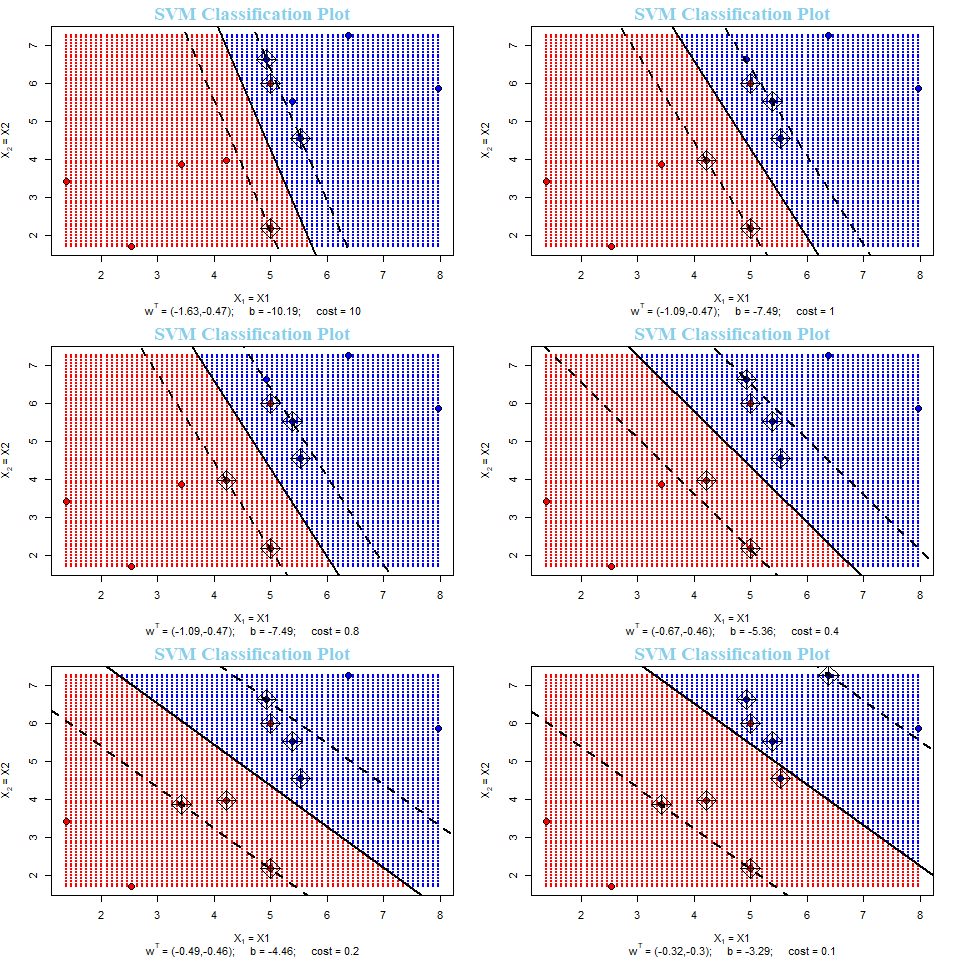

```r
par(mfrow = c(3,2))
for (C in c(10, 1, 0.8, 0.4, 0.2, 0.1)){
svm(y~., data = df,
    kernel = "linear",
    cost = C,
    scale = FALSE) %>%
   plot_svm( x = df[,1:2], y = df$y)

}
par(mfrow = c(1,1))
```

Wie man sehen kann, bewirkt der eine neu hinzugefügte Ausreißer eine starke verschiebung der Hyperbene. Durch den Parameter `cost` kann dieses jedoch ausgeglichen werden. Im nächsten Abschnitt soll eine Methode vorgestellt werden, um die optimale Wahl der Parameters zu gewährleisten.

## Motor Trend Car Road Tests

> The data was extracted from the 1974 Motor Trend US magazine, and comprises fuel consumption and 10 aspects of automobile design and performance for 32 automobiles (1973-74 models).
- vs = V/S
- disp Displacement (cu.in.)
- qsec = 1/4 mile time

```r
set.seed(1807)
# Auswahl  der Merkmale und Klassen
data <- mtcars %>%
  select(disp, qsec , vs) %>%
  within({ vs = factor(vs, labels = c("-1", "1"))})
head(data)
```

|  | disp | qsec | vs |
| --- | --- | --- | --- |
| Mazda RX4 | 160 | 16.46 | -1 |
| Mazda RX4 Wag | 160 | 17.02 | -1 |
| Datsun 710 | 108 | 18.61 | 1 |
| Hornet 4 Drive | 258 | 19.44 | 1 |
| Hornet Sportabout | 360 | 17.02 | -1 |
| Valiant | 225 | 20.22 | 1 |

Die Daten werden für die Validierung des Models in Test und Trainigsdaten gesplitted.

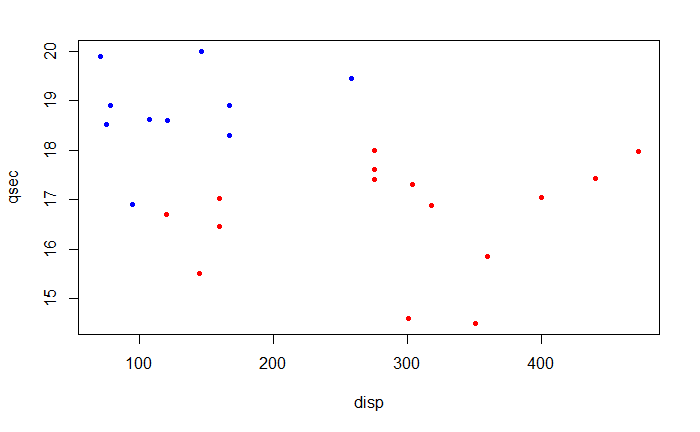

```r
# Splitten der Daten in Test und Trainingsdaten
train <- sample(c(1:nrow(data)), size = .8 * nrow(data) )
test <- -train
data_train <- data[train,]
data_test <- data[test,]
# plotten der Trainingsdaten
plot(data_train[,1:2], col = (3 + as.numeric(as.character(data_train$vs))), pch = 20)
```

### Cross-Validation

Die optimale Wahl des Parameters `cost` soll durch *Cross-Validation* bestimmt werden. Hierfür bietet das Paket `e1071` die Funktion `tune()` oder `tune.svm()` eine Lösung.  
Es werden also lineare SVMs mit verschiedene Parameter `cost` verglichen.

```r
set.seed(1987)
tune_out <- tune.svm(vs~.,
                    data = data_train,
                    kernel ="linear",
                    scale = FALSE,
                    cost = c(0.001, 0.01, 0.1, 1, 10)
                    )
summary(tune_out)
```

```
Parameter tuning of svm:

- sampling method: 10-fold cross validation

- best parameters:
 cost
  0.1

- best performance: 0.1

- Detailed performance results:
   cost     error dispersion
1 1e-03 0.2166667  0.3337960
2 1e-02 0.2166667  0.3337960
3 1e-01 0.1000000  0.3162278
4 1e+00 0.1000000  0.2108185
5 1e+01 0.1000000  0.2108185
```

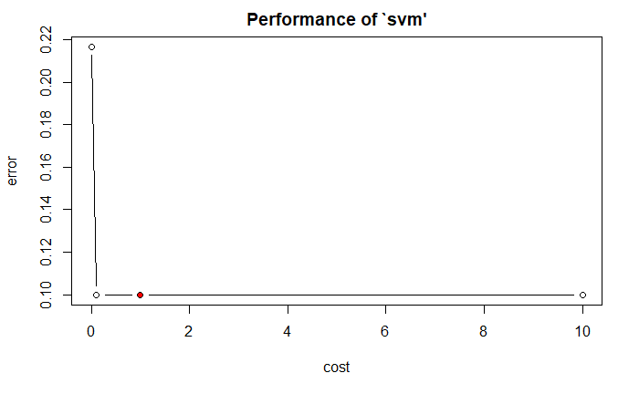

```r
plot(tune_out)
points(tune_out$best.parameters, col = "red", pch = 20)
```

### Plotten des besten Models

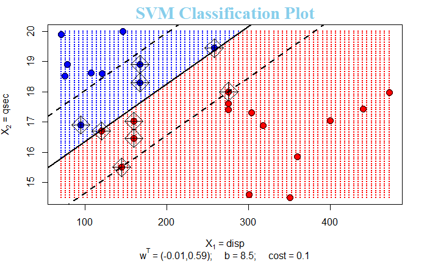

```r
tune_out$best.model %>% plot_svm(x = data_train[,1:2], y = data_train$vs)
```

### Kontingenztafel

```r
data_test$vs_pred <- predict(tune_out$best.model, data_test[1:2])
table(predict = data_test$vs_pred, truth = data_test$vs)
```

```
       truth
predict -1 1
     -1  3 0
     1   0 4
```

Keines der 7 Testdaten wird durch die beste SVM mit `cost = 0.1` falsch klassifiziert.

In der Grafik werden die Test Punkte in großen Kreisen mit den dazugehörigen Werten für $y^{(i)}$ geplotten, um das Resultat visuel zu veranschaulichen.

```r
tune_out$best.model %>% plot_svm(x = data_train[,1:2], y = data_train$vs)
points(data_test, pch = 21, cex = 3.5, bg = c("red", "blue")[data_test$vs])
```

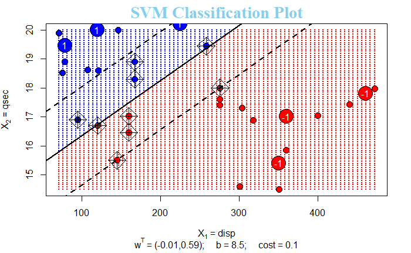

```r
text(data_test, labels = data_test$vs, col = "white")
```

Wie sieht es aus, mit `cost = 0.01`?

```r
svmfit = svm(vs~.,
             data = data_train,
             kernel = "linear",
             cost = 0.01,
             scale = FALSE)
data_test$vs_pred <- predict(svmfit, data_test[1:2])
table(predict = data_test$vs_pred, truth = data_test$vs)
```

```
       truth
predict -1 1
     -1  3 1
     1   0 3
```

Eine der Testdatenpunkte wird durch die Parametrisierung 0.01 falsch klassifiziert.

```r
svmfit %>% plot_svm(x = data_train[,1:2], y = data_train$vs)
points(data_test, pch = 21, cex = 3.5, bg = c("red", "blue")[data_test$vs])
```

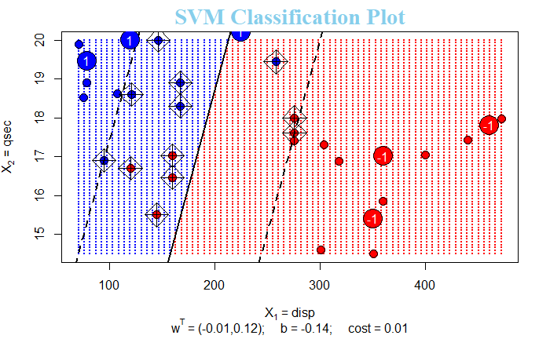

```r
text(data_test, labels = data_test$vs, col = "white")
```

### Grafische Auswirkung des optimalen C

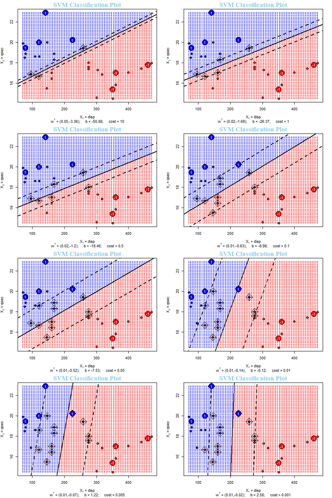

```r
par(mfrow = c(4,2))
for (C in c(10, 1, 0.5, 0.1, 0.05, 0.01, 0.005, 0.001)){
svm(vs~., data = data,
    kernel = "linear",
    cost = C,
    scale = FALSE) %>%
   plot_svm( x = data[,1:2], y = data$vs)
   points(data_test, pch = 21, cex = 3.5, bg = c("red", "blue")[data_test$vs])
   text(data_test, labels = data_test$vs, col = "white")

}
par(mfrow = c(1,1))
```